# Modelamiento-Prediccion

Andres Garcia

26/11/2022

## Comportamiento Accidentes reales vs Predichos 2019

En la siguiente gráfica se muestra la cantidad de accidentes ocurridos a lo largo del año 2019.

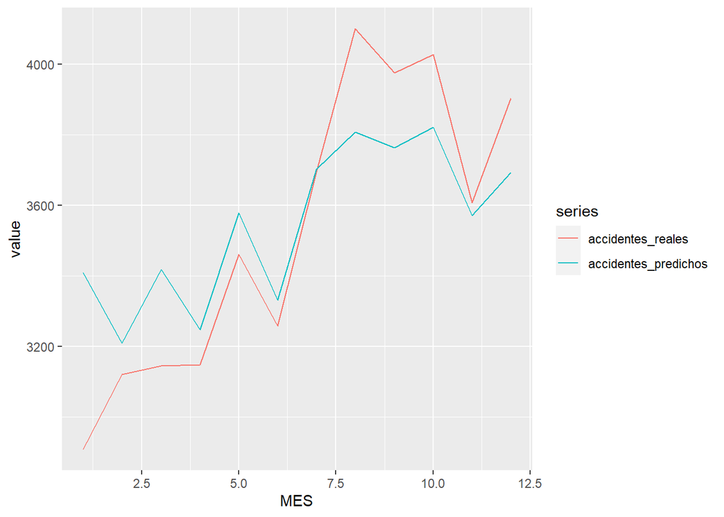

Para el año 2019 la cantidad de accidentes predichos por el modelo se asemeja a la cantidad de accidentes reales ocurridos en el mismo año. Se puede observar que los accidentes predichos por el modelo tienen un patrón de comportamiento similar a los datos reales pasado el més 4. A pesar de que anterior al mes 4 existen diferencias considerables, la similitud general de ambos nos lleva a concluir que el modelo hace predicciones en un rango aceptable.

## Comportamiento Accidentes reales vs Predichos 2020

En la siguiente gráfica se muestra la cantidad de accidentes ocurridos a lo largo del año 2020.

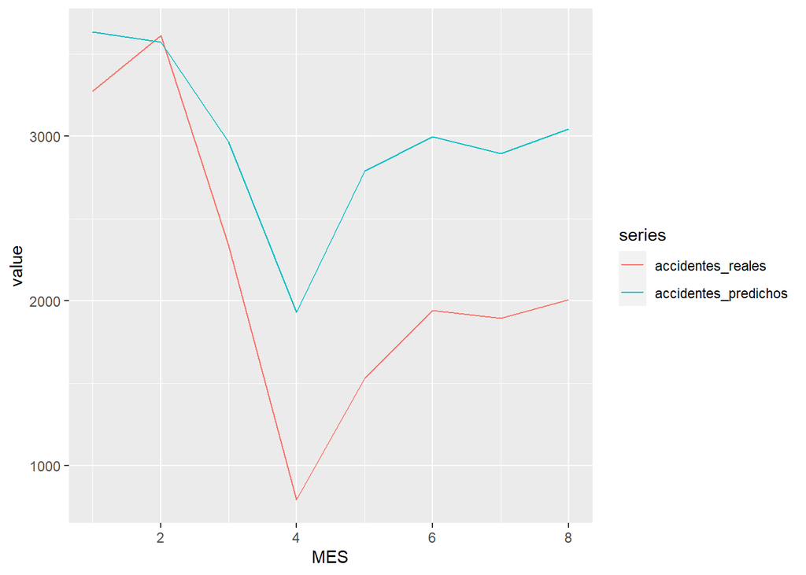

# Prediccion en los Años 2021 y 2022

# Predicion diaria 2021

A continuación se muestra una tabla con las primeras 10 observaciones de las predicciones diarias obtenidas para el año 2021.

```
## # A tibble: 2,190 x 5
## # Groups:   FECHA, DIA_SEMANA, CLASE [2,190]
##    FECHA      DIA_SEMANA CLASE             FESTIVIDAD NUM_ACC
##    <date>     <fct>      <fct>             <fct>        <dbl>
##  1 2021-01-01 viernes    Atropello         SI              22
##  2 2021-01-01 viernes    Caida de Ocupante SI              20
##  3 2021-01-01 viernes    Choque            SI              78
##  4 2021-01-01 viernes    Incendio          SI               8
##  5 2021-01-01 viernes    Otro              SI              22
##  6 2021-01-01 viernes    Volcamiento       SI              11
##  7 2021-01-02 sabado     Atropello         NO              25
##  8 2021-01-02 sabado     Caida de Ocupante NO              25
##  9 2021-01-02 sabado     Choque            NO              89
## 10 2021-01-02 sabado     Incendio          NO               9
## # ... with 2,180 more rows
```

# Prediccion diaria 2022

Se presenta también la tabla referente a las primeras 10 observaciones de las predicciones diarias obtenidas para el año 2022.

[output not shown]

```
## # A tibble: 2,190 x 5
## # Groups:   FECHA, DIA_SEMANA, CLASE [2,190]
##    FECHA      DIA_SEMANA CLASE             FESTIVIDAD NUM_ACC
##    <date>     <fct>      <fct>             <fct>        <dbl>
##  1 2022-01-01 sabado     Atropello         SI              20
##  2 2022-01-01 sabado     Caida de Ocupante SI              17
##  3 2022-01-01 sabado     Choque            SI              71
##  4 2022-01-01 sabado     Incendio          SI               7
##  5 2022-01-01 sabado     Otro              SI              20
##  6 2022-01-01 sabado     Volcamiento       SI              10
##  7 2022-01-02 domingo    Atropello         NO              16
##  8 2022-01-02 domingo    Caida de Ocupante NO              14
##  9 2022-01-02 domingo    Choque            NO              63
## 10 2022-01-02 domingo    Incendio          NO               5
## # ... with 2,180 more rows
```

# Prediccion semanal 2021

A continuación se muestra una tabla con las primeras 10 observaciones de las predicciones semanales obtenidas para el año 2021.

```
## # A tibble: 432 x 4
## # Groups:   SEMANA, CLASE [318]
##    SEMANA CLASE             FESTIVIDAD NRO_TOTAL_ACCID
##     <int> <fct>             <fct>                <dbl>
##  1      1 Atropello         NO                      50
##  2      1 Atropello         SI                      18
##  3      1 Caida de Ocupante NO                      50
##  4      1 Caida de Ocupante SI                      16
##  5      1 Choque            NO                     176
##  6      1 Choque            SI                      71
##  7      1 Incendio          NO                      18
##  8      1 Incendio          SI                       7
##  9      1 Otro              NO                      50
## 10      1 Otro              SI                      18
## # ... with 422 more rows
```

# Prediccion semanal 2022

Se presenta también la tabla referente a las primeras 10 observaciones de las predicciones semanales obtenidas para el año 2022.

```
## # A tibble: 444 x 4
## # Groups:   SEMANA, CLASE [318]
##    SEMANA CLASE             FESTIVIDAD NRO_TOTAL_ACCID
##     <int> <fct>             <fct>                <dbl>
##  1      1 Atropello         NO                      25
##  2      1 Atropello         SI                      18
##  3      1 Caida de Ocupante NO                      25
##  4      1 Caida de Ocupante SI                      16
##  5      1 Choque            NO                      88
##  6      1 Choque            SI                      71
##  7      1 Incendio          NO                       9
##  8      1 Incendio          SI                       7
##  9      1 Otro              NO                      25
## 10      1 Otro              SI                      18
## # ... with 434 more rows
```

# Prediccion mensual 2021

A continuación se muestra una tabla con las primeras 10 observaciones de las predicciones mensuales obtenidas para el año 2021.

```
## # A tibble: 132 x 4
## # Groups:   MES, CLASE [72]
##      MES CLASE             FESTIVIDAD NRO_TOTAL_ACCID
##    <int> <fct>             <fct>                <dbl>
##  1     1 Atropello         NO                     725
##  2     1 Atropello         SI                      36
##  3     1 Caida de Ocupante NO                     725
##  4     1 Caida de Ocupante SI                      32
##  5     1 Choque            NO                    2552
##  6     1 Choque            SI                     142
##  7     1 Incendio          NO                     261
##  8     1 Incendio          SI                      14
##  9     1 Otro              NO                     725
## 10     1 Otro              SI                      36
## # ... with 122 more rows
```

# prediccion mensual 2022

Se presenta también la tabla referente a las primeras 10 observaciones de las predicciones mensuales obtenidas para el año 2022.

[output not shown]